# Talks – Making Fisher Work: compresión en tiempo de entrenamiento para 3D Gaussian Splatting

INF479 · Seminario de Softcomputing · Análisis de artículo

Making Fisher Work:  
Train-Time Compression for 3D Gaussian Splatting

P G Arun Madhav · Chandra Sekhar Seelamantula

Department of Electrical Engineering, Indian Institute of Science, Bangalore

IEEE International Conference on Image Processing (ICIP), 2026 · DOI: 10.1109/ICIP61757.2026.11630029

Presenta: **Francisco Alfaro Medina** , Universidad Técnica Federico Santa María

## 3D-GS logra tiempo real a costa de cientos de MB de almacenamiento

Contexto y problema

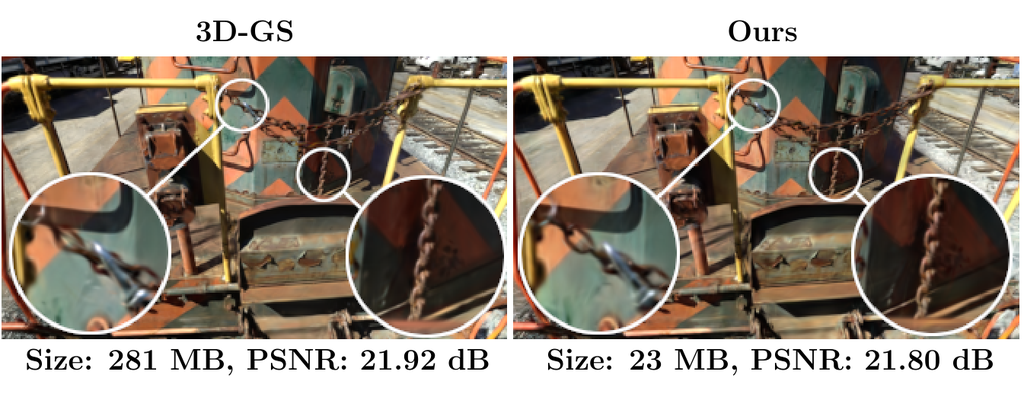

Escena *train*, Tanks&Temples (Fig. 1 del artículo).

Escala

Una reconstrucción de calidad suele requerir **millones de primitivas** [1].

Presupuesto

Cada gaussiana guarda **59 valores**. Según el artículo, los armónicos esféricos superan el **80 %**.

Tamaño = **número de primitivas** × **bytes por primitiva**: la compresión debe actuar sobre ambos factores.

## La compresión previa no regula cuándo emerge la redundancia

Brecha, objetivo y contribuciones

Entrenamiento progresivo

Estabiliza, pero no busca regular la redundancia [5, 11].

Poda

PUP [7] deriva un puntaje del Hessiano, aplicable solo cerca de converger.

Cuantización

La mayoría aplica esquemas genéricos a parámetros heterogéneos.

**Objetivo:** controlar cómo emerge la redundancia durante el entrenamiento, con dos contribuciones (C1 y C2).

**C1 · Pirámide (PPT)**Supervisión de grueso a fino.

→

**Residual bajo**Temprano, en niveles gruesos.

→

**Fisher utilizable**Aproximación del Hessiano.

→

**Poda en entrenamiento**Menos **primitivas**.

**C2 · Correlación**Distinta en cada grupo.

→

**Cuantización (CAQ)**Menos **bytes por primitiva**.

→

**≈95 % menos de almacenamiento**Promedio informado frente a 3D-GS.

## La supervisión piramidal adelanta el régimen de residual bajo

Metodología · Paso 1 · Entrenamiento piramidal progresivo

Nivel 2 Nivel 1 Nivel 0: resolución completa (desde la iteración 10.000)

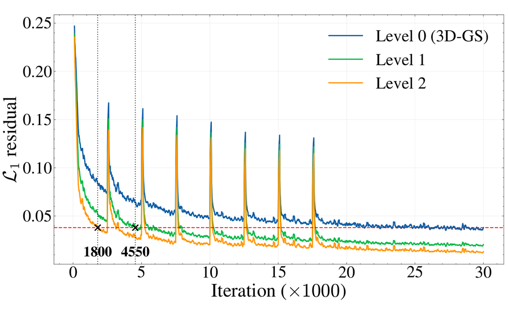

Tanks&Temples. Línea roja: 3D-GS convergido (Fig. 3).

1.800 primer cruce, nivel 2

4.550 primer cruce, nivel 1

$$L^\ell = (1-\lambda)L_1^\ell + \lambda L_{\text{D-SSIM}}^\ell$$

$f$: suavizado gaussiano y reducción a la mitad; $f_\ell$: $f$ aplicada $\ell$ veces.

La causa de los picos visibles no figura en el PDF.

## Un residual bajo reduce el Hessiano a un puntaje por gaussiana

Metodología · Paso 2 · Sensibilidad basada en Fisher

$$\nabla_G^2 L_2 = \sum_{i=1}^{K}\Big[\underbrace{J_{f_{\scriptstyle\ell}}\nabla_G I_G(\phi_i)\,\nabla_G I_G(\phi_i)^{\top} J_{f_{\scriptstyle\ell}}^{\top}}_{\text{se conserva: aproximación de Fisher}} + \underbrace{\big(f_\ell(I_G(\phi_i)) - f_\ell(I_i)\big)\nabla_G^2 f_\ell(I_G(\phi_i))}_{\text{depende del residual: empíricamente despreciable}}\Big]$$

**Un bloque por gaussiana**

$$H_j = \sum_{i=1}^{K} J_{f_{\scriptstyle\ell}}\nabla_{G_{\scriptstyle j}} I_G(\phi_i)\,\nabla_{G_{\scriptstyle j}} I_G(\phi_i)^{\top} J_{f_{\scriptstyle\ell}}^{\top}$$

**Un número por gaussiana**

$$U_j = \log |H_j|$$

$U_j$ alto: **se conserva**. $U_j$ bajo: se considera redundante y **se poda**.

## Un mismo puntaje sustenta dos regímenes de poda

Metodología · Paso 2 · Poda

Poda piramidal

Se intercala con los niveles. Evita que la redundancia de la etapa gruesa **sesgue el ajuste fino**.

Poda iterativa

Cada **3.000 iteraciones**, entre la **21.000** y la **27.000**, cuando los rankings ya son estables.

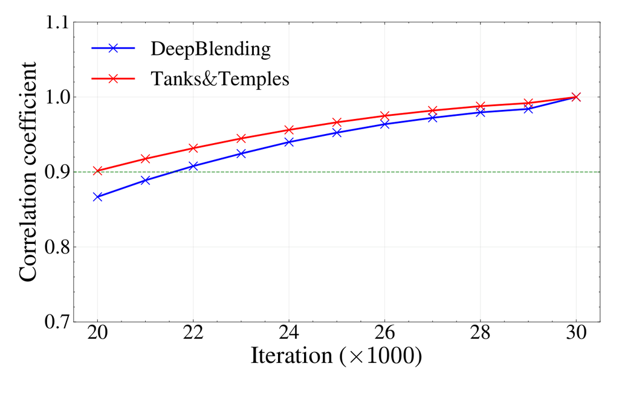

Spearman frente a un 3D-GS convergido (Fig. 4).

Esta figura comienza en la iteración 20.000: **no cubre las etapas gruesas**.

## CAQ adapta la cuantización a la correlación de cada grupo

Metodología · Paso 3 · Cuantización consciente de la correlación

Rotación $r$ y opacidad $o$

**Decorrelacionados** [5]: bastan latentes escalares y un decodificador lineal compacto.

Armónicos esféricos $h$

**Fuerte correlación entre canales** [16]: un decodificador basado en DFT [17] los lleva a una base de frecuencia.

$$h = \mathcal{D}_{\text{DFT}}\big(\operatorname{STE}(h_\ell)\big), \qquad r, o = \mathcal{D}\big(\operatorname{STE}(r_\ell, o_\ell)\big)$$

**Durante el entrenamiento**

El STE [18] discretiza hacia adelante y conserva el gradiente hacia atrás.

**Después del entrenamiento**

Los latentes se discretizan, se codifican por entropía y se guardan con sus decodificadores.

## ≈95 % menos que 3D-GS, aunque Compact obtiene modelos menores

Resultados · Calidad frente a tamaño lectura propia

[figure not shown]

PropuestoCompactOtrosVertical: PSNR (dB) · Mejor: arriba a la izquierda · −x %: frente a 3D-GS · Datos: Tabla 1

Frente a Compact

Pesa **17–26 % más** y gana **de 0,05 a 0,16 dB**.

Frente a PUP

**1,8–2,3 veces** más pequeño y **de 0,34 a 1,02 dB** mejor.

Frente a 3D-GS

Pierde **0,43** y **0,29 dB** en dos datasets; gana **0,39 dB** en otro.

## CAQ reduce los bytes por primitiva; PPT y la poda, las primitivas

Resultados · Ablación en una sola escena (bonsai) lectura propia

| Configuración | PSNR | LPIPS | Primitivas | MB | ≈B/prim. |
| --- | --- | --- | --- | --- | --- |
| 3D-GS | 32,25 | 0,181 | 1,25 M | 294,55 | ≈236 |
| + CAQ | 31,36 | 0,216 | 0,98 M | 44,22 | ≈45 |
| + PPT | 31,35 | 0,216 | 0,80 M | 36,82 | ≈46 |
| + Poda piramidal | 30,94 | 0,219 | 0,66 M | 30,88 | ≈47 |
| + Poda iterativa | 30,91 | 0,224 | 0,33 M | 15,24 | ≈46 |
| Propuesto | 30,92 | 0,224 | 0,33 M | 15,28 | ≈46 |

≈B/prim.: MB ÷ conteo redondeado (0,33 M puede ser 0,325–0,335 M).

CAQ: de ≈236 a ≈45 B

El tamaño cae **85 %** de una vez.

PPT y podas: 0,98 → 0,33 M

Unas **3 veces** menos primitivas.

Costo: −1,33 dB

LPIPS de 0,181 a 0,224.

## Aporte metodológico relevante, con validación aún parcial

Análisis crítico y pertinencia lectura propia

Análisis crítico

- **Fortaleza:** hipótesis medida y mejora clara sobre PUP.
- **Limitación declarada:** supone residuales pequeños en los niveles gruesos.
- **Propio:** la Fig. 4 no valida las etapas gruesas.
- **Propio:** LPIPS peor que 3D-GS en los tres datasets; Tabla 1 sin dispersión ni HAC++ [10].

Pertinencia para la asignatura

- **Aprendizaje por gradiente** de una representación.
- **Cuantización entrenable** con STE [18].
- **Poda por sensibilidad**, análoga a podar redes.
- **Optimización orientada al tamaño:** poda y cuantización, sin término de tamaño en la pérdida.

El artículo **no usa** lógica difusa ni algoritmos evolutivos.

## Conclusión: el momento de comprimir también es una variable de diseño

Conclusiones y extensiones

Aporta

Lleva la poda basada en Fisher **al entrenamiento**.

Logra

**≈95 %** menos que 3D-GS, con calidad competitiva entre compresores.

Falta

Validar los puntajes en las etapas gruesas y en más escenas. lectura propia

**Extensión de los autores**

Cronogramas adaptativos y otras estrategias de cuantización.

**Hipótesis propia, sin evaluar**

Ajustar cronogramas y tasas con metaheurísticas o reglas difusas. lectura propia

Muchas gracias

¿Preguntas?

**Francisco Alfaro Medina** · Universidad Técnica Federico Santa María

Artículo analizado

Making Fisher Work: Train-Time Compression for 3D Gaussian Splatting

P G Arun Madhav y Chandra Sekhar Seelamantula

IEEE ICIP 2026

DOI: 10.1109/ICIP61757.2026.11630029

## Tabla 1 completa: ningún método gana en todo

Respaldo · Resultados

| Método | Mip-NeRF 360 [19] PSNR↑ | Mip-NeRF 360 [19] SSIM↑ | Mip-NeRF 360 [19] LPIPS↓ | Mip-NeRF 360 [19] MB↓ | Tanks&Temples [20] PSNR↑ | Tanks&Temples [20] SSIM↑ | Tanks&Temples [20] LPIPS↓ | Tanks&Temples [20] MB↓ | Deep Blending [21] PSNR↑ | Deep Blending [21] SSIM↑ | Deep Blending [21] LPIPS↓ | Deep Blending [21] MB↓ |
| --- | --- | --- | --- | --- | --- | --- | --- | --- | --- | --- | --- | --- |
| 3D-GS [1] | 27,44 | 0,813 | 0,218 | 822,6 | 23,67 | 0,844 | 0,179 | 452,4 | 29,48 | 0,900 | 0,246 | 692,5 |
| Compact [4] | 26,95 | 0,797 | 0,244 | 26,31 | 23,33 | 0,831 | 0,202 | 18,97 | 29,71 | 0,901 | 0,257 | 25,75 |
| EAGLES [5] | 27,07 | 0,801 | 0,240 | 59,49 | 23,14 | 0,833 | 0,203 | 30,18 | 29,72 | 0,906 | 0,249 | 54,45 |
| LightGaussian [6] | 26,90 | 0,800 | 0,240 | 53,96 | 23,32 | 0,829 | 0,204 | 29,94 | 29,12 | 0,895 | 0,262 | 45,25 |
| PUP [7] | 26,67 | 0,786 | 0,271 | 74,65 | 22,72 | 0,801 | 0,244 | 43,37 | 28,85 | 0,881 | 0,301 | 69,98 |
| Propuesto | 27,01 | 0,801 | 0,239 | 32,78 | 23,38 | 0,837 | 0,202 | 23,93 | 29,87 | 0,912 | 0,248 | 30,07 |

MejorSegundoMarcado del artículo; 3D-GS queda fuera del ranking.

96,0 % reducción, Mip-NeRF 360

94,7 % reducción, Tanks&Temples

95,7 % reducción, Deep Blending

## Tabla 2 completa: la ablación incluye todas las métricas

Respaldo · Ablación en bonsai

| Configuración | PSNR↑ | SSIM↑ | LPIPS↓ | Primitivas↓ | MB↓ |
| --- | --- | --- | --- | --- | --- |
| 3D-GS | 32,25 | 0,946 | 0,181 | 1,25 M | 294,55 |
| + CAQ | 31,36 | 0,937 | 0,216 | 0,98 M | 44,22 |
| + PPT | 31,35 | 0,936 | 0,216 | 0,80 M | 36,82 |
| + PP | 30,94 | 0,933 | 0,219 | 0,66 M | 30,88 |
| + IP | 30,91 | 0,932 | 0,224 | 0,33 M | 15,24 |
| Propuesto | 30,92 | 0,932 | 0,224 | 0,33 M | 15,28 |

Tabla 2 del artículo, escena bonsai. PP: poda piramidal. IP: poda iterativa.

## Todo ocurre dentro de un único lazo de entrenamiento

Respaldo · Fig. 2

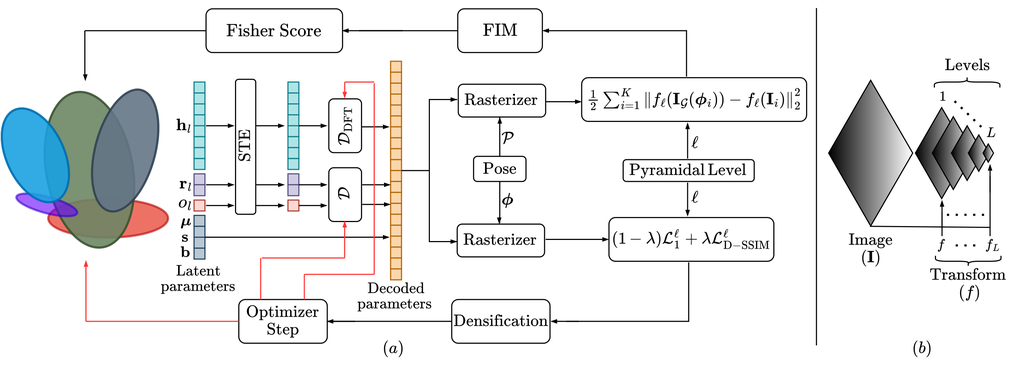

Izquierda: latentes → STE → decodificadores Abajo: pérdida → densificación → optimizador Arriba: error L2 → FIM → puntaje → poda

## Los armónicos esféricos dominan el presupuesto por gaussiana

Respaldo · Qué hay que comprimir

$\mu_i \in \mathbb{R}^{3}$ centro

$s_i \in \mathbb{R}^{3}$ escala

$r_i \in \mathbb{R}^{4}$ rotación

$b_i \in \mathbb{R}^{3}$ color base

$h_i \in \mathbb{R}^{15\times 3}$ armónicos

$o_i \in \mathbb{R}$ opacidad

**Pérdida (Ec. 2)**

$$L = (1-\lambda)\,L_1 + \lambda\,L_{\text{D-SSIM}}$$

con $\lambda = 0{,}2$ típicamente.

**45/59 ≈ 76 %** sin contar el color base; **48/59 ≈ 81 %** si se incluye el grado 0, coherente con el «>80 %» del paper. lectura propia

## Referencias

Respaldo · Numeración del artículo

**Artículo.** P. G. Arun Madhav y C. S. Seelamantula, «Making Fisher Work: Train-Time Compression for 3D Gaussian Splatting», IEEE ICIP, 2026.

**[1]** Kerbl et al., «3D Gaussian Splatting for Real-Time Radiance Field Rendering», *ACM TOG*, 2023.

**[4]** Lee et al., «Compact 3D Gaussian Representation for Radiance Field», arXiv:2311.13681, 2023.

**[5]** Girish et al., «EAGLES», ECCV, 2024.

**[6]** Fan et al., «LightGaussian», NeurIPS, 2024.

**[7]** Hanson et al., «PUP 3D-GS», arXiv:2406.10219, 2024.

**[9]** Liu et al., «CompGS», ACM Multimedia, 2024.

**[10]** Chen et al., «HAC++», arXiv:2501.12255, 2025.

**[11]** Farooq et al., «Optimized 3D Gaussian Splatting using Coarse-to-Fine Image Frequency Modulation», CVMP, 2025.

**[16]** Seeley, «Spherical Harmonics», *Amer. Math. Monthly*, 1966.

**[17]** Moczulski et al., «ACDC: A Structured Efficient Linear Layer», 2016.

**[18]** Huh et al., «Straightening Out the Straight-Through Estimator», ICML, 2023.

**[19]** Barron et al., «Mip-NeRF 360», CVPR, 2022.

**[20]** Knapitsch et al., «Tanks and Temples», *ACM TOG*, 2017.

**[21]** Hedman et al., «Deep Blending for Free-Viewpoint Image-Based Rendering», *ACM TOG*, 2018.